# Rapport du projet de M1

Combien de temps pour faire une espèce ?

Wiam Chaoui

Sophie Manuel

Stéphane Sadio

2021

La classification du vivant est depuis longtemps un vrai casse-tête pour les biologistes, surtout en ce qui concerne la notion d’*espèce*. De fait, il existe plusieurs définitions du mot espèce, ce qui rend encore plus compliqué un concensus. C’est pour cela que dans la suite nous ne nous étendrons pas sur cette notion et on se concentrera que sur des espèces prédéfinies.

Les *arbres phylogénétiques* sont des outils permettant de représenter graphiquement certaines données de classification. En effet, ils présentent les relations de parenté entre *espèces*. On retrouve dessous différentes espèces actuelles, mais aussi leurs ancêtres communs (les *branchements évolutifs* qui correspondent à l’apparition d’une nouvelle homologie), ou encore la durée avant l’apparition d’une nouvelle espèce qui est donnée par la longeur des branches.

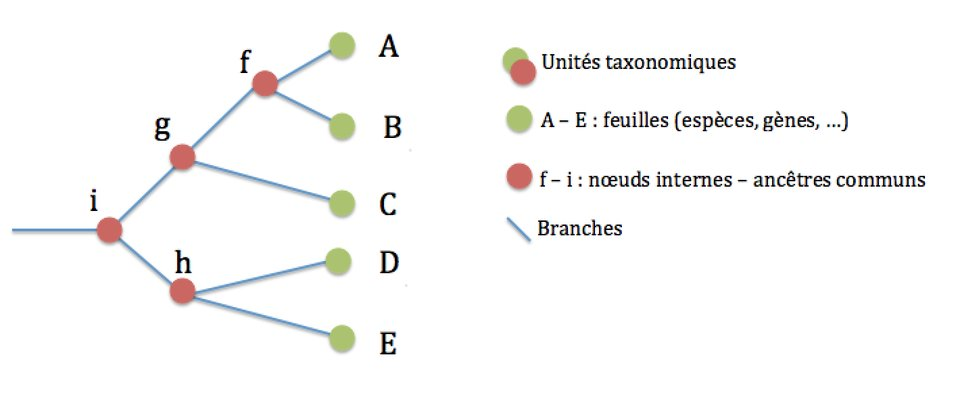

Dans la suite, on s’intéresse aux *branchements évolutifs*. On suppose qu’un branchement évolutif apparaît après une durée aléatoire d’une loi fixée $\mu$ indépendamment du passé et du futur évolutif des espèces.  
Quelle est cette loi $\mu$? Sa variance ? Sa moyenne ?

On observe des branchements successifs qui composent l’arbre phylogénétique et à partir de ces données quantitatives observées, on veut estimer la fonction de densité $f$ qui donne la probabilité qu’un nouveau branchement évolutif apparaisse après un certain temps.

Formellement, on a un échantillon $X$={$X_1,\dots,X_n$} de longueurs de branche observées qui ont pour une fonction de densité $f \in \mathcal F$ où $\mathcal F$ est un espace fonctionnel. On cherche à estimer cette fonction densité $f$ sur laquelle on fait le moins d’hypothèses possibles. On fera seulement les hypothèses d’existence, de continuité et de positivité de la fonction $f$.

D’où le choix du modèle suivant $\{P=P_f,~f\in \mathcal F\}$ qui revient à faire une estimation non-paramétrique de la densité. Ce qui nous mène à la problématique de notre sujet.

Comment estimer la loi de densité de la création d’une nouvelle espèce avec une méthode d’estimation non-paramétrique ?

Pour commencer, nous introduirons les méthodes d’estimations non-paramétriques, en donnant quelques définitions et en présentant quelques types d’estimateurs. Ensuite, nous allons approfondir sur les estimateurs de densité à noyau en parlant de leur évaluation et des méthodes adaptatives. Enfin, pour répondre à la problématique, on cherchera à implémenter un estimateur à noyau adaptatif, de type Goldenshluger-Lepski puis l’utiliser sur des données d’arbres phylogénétiques.

En statistique, on parle d’estimation quand on cherche à trouver certains paramètres inconnus caractérisant une distribution à partir d’un échantillon de données observées en se basant sur différentes méthodes. On se tourne vers l’estimation non-paramétrique lorsqu’on traite des paramètres à dimension infini. Ce qui est bien notre cas, comme on cherche à estimer une fonction densité qui appartient à un espace fonctionnel.  
On présente dans la suite une courte introduction à l’estimation non paramétrique. On introduira ensuite les deux classes principales de l’estimation fonctionnelle (l’estimation par projection et l’estimation à noyau) afin de discuter de ces deux classes et expliquer pourquoi on fait le choix de l’estimation à noyau.

L’estimation ici concerne donc la fonction elle même plutôt que les paramètres, ce qui explique le nom d’estimation non-paramétrique.

Une des premières estimations non-paramétriques de la fonction de densité qui est possible est l’histogramme.

L’histogramme fait partie de la famille des estimations à noyau qu’on détaillera plus tard.

Nous traiterons deux grandes familles de méthodes pour estimer une fonction densité : - L’estimation par projection et - L’estimation par noyau.

Dans la suite on procèdera à la méthode la plus fréquemment utilisée pour l’estimation d’une densité : L’estimation à noyau.

Avant de commencer cette partie on va d’abord introduire quelques notions et définitions

Nous nous intéressons au risque quadratique ponctuel de $\hat{f}_n$, i.e étant donné $x_0 \in \mathbb{R}$

$$R(\hat {f}_n, f) = \mathbb{E}[|\hat {f}_n(x_0) - f(x_0)|^2]$$

Rappelons la décomposition “biais au carré-variance” du risque quadratique:

$$\mathbb{E}[|\hat {f}_n(x_0) - f(x_0)|^2] = (\mathbb{E}[\hat {f}_n(x_0)] - f(x_0))^2 + \mathbb{V}(\hat {f}_n(x_0))$$

On a bien trouvé que :
$$R(\hat{f},f)=biais^2+\mathbb Var$$

Donc, afin de minimiser l’expression du risque le choix de h est très influent et même plus crucial pour la qualité de l’estimateur que celui de la noyau $K$. On doit chercher le meilleur compromis biais-variance pour avoir un risque minimal. Un paramètre trop faible provoque l’apparition de détails artificiels sur le graph de l’estimateur (La variance devient trop grande), par contre si on prend une valeur de h très grande on aura la majorité des caractéristiques effacées.

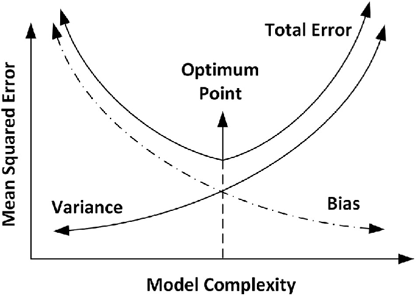

Bias-variance-trade-off

On a introduit précédemment la notion de l’estimation de la densité qui dépend d’un paramètre de lissage h. Soit $(\hat{f_h})_{h\in \mathcal H}$ une famille des estimateurs de la vrai fonction densité $f$ . La question qui se pose est donc la suivante : comment peut on construire un estimateur à risque optimal à partir de cette famille (en prenant en considération les observations) ? Dans cette partie et afin de repondre a la question qu’on a poser on va discuter au premier temps du choix du noyau. Ensuite, on va introduire deux méthodes pour le choix du paramètre de lissage h. (j’ai un problème avec cette partie)

L’estimation de densité nécessite le choix de la fentêtre qu’on note h.En statistique non-paramétrique, ils éxistent plusieurs méthodes et critéres de qualité pour le choix de la fêntere.

On présente dans la suite deux méthodes: Méthode de validation croisée. Méthode de Goldenshluger-Lepski.

Le choix de la fenêtre dans la section précédente est critiquable: comme on l’a mentionné, il dépend de la régularité la fonction $f$ qui est inconnue dans notre cas. On peut donc essayer d’estimer cette fenêtre idéale par un estimateur $\hat{h}$. De façon à souligner la dépendance à la fonction, on va noter $\hat{f}_{n,h}$ l’estimateur associé à un choix de fenêtre $h$. L’estimateur final sera $\hat{f}_{n,\hat{h}}$, une fois le choix de $\hat{h}$ fait.*on fait un choix sur h ?** On cherche à minimiser en $h$ le risque quadratique pour la distance $L_2$ :

$$\begin{aligned}
R(\hat {f}_{n,h})&=\mathbb{E}[\begin{Vmatrix}\hat {f}_{n,h}-f\end{Vmatrix}_2^2]\\
&= \mathbb{E}[\begin{Vmatrix}\hat {f}_{n,h}\end{Vmatrix}_2^2] -2~\mathbb{E}[\int \hat {f}_{n,h}(x)f(x)dx] +\begin{Vmatrix}f\end{Vmatrix}_2^2
\end{aligned}$$

Or la fonction $f$ étant inconnue, ce risque n’est pas calculable à partir des données. On cherche donc à estimer ce risque en utilisant uniquement les données. Remarquons tout de suite que minimiser en $h$ la quantité $R(\hat {f}_{n,h}, f)$ est équivalent à minimiser en $h$ la quantité $R(\hat {f}_{n,h}, f)-\begin{Vmatrix}f\end{Vmatrix}_2^2$. On va en fait remplacer la minimisation de la quantité inconnue $R(\hat {f}_{n,h}, f)-\begin{Vmatrix}f\end{Vmatrix}_2^2$ par la minimisation d’un estimateur $\hat {R}(h)$ de cette quantité. Plus précisément on va chercher un estimateur sans biais de cette expression:

$$\mathbb{E}[\begin{Vmatrix}\hat {f}_{n,h}\end{Vmatrix}_2^2] -2~\mathbb{E}[\int \hat {f}_{n,h}(x)f(x)dx]$$

Le premier terme admet $\begin{Vmatrix}\hat {f}_{n,h}\end{Vmatrix}_2^2$ comme estimateur trivial (d’après la propriété des estimateurs sans biais : $\mathbb{E}[\hat {\beta}]=\beta$). Il reste à trouver un estimateur sans biais du second terme. Pour cela, nous admettons par construction l’estimateur sans biais $\hat {G}$ définit en tout points sauf en $X_i$ (c’est le principe du Leave-one-out):

$$\hat{G}(X_1,\dots,X_{i-1},X_{i+1},\dots,X_n) = \frac{1}{n}\sum_{i=1}^n\hat {f}_{n,h}^{(-i)}(X_i)$$
avec :

$$\hat {f}_{n,h}^{(-i)}(x)= \frac{1}{n-1}\frac{1}{h}\sum_{j=1,j\ne i}^nK(\frac{x-X_j}{h})$$

Montrons que $\mathbb{E}(\hat{G}(X_1,\dots,X_{i-1},X_{i+1},\dots,X_n))=\mathbb{E}[\int \hat{f}_{n,h}(x)f(x)dx]$. Comme les $X_i$ sont i.i.d., d’une part nous avons :
$$\begin{aligned}
\mathbb{E}[\int \hat {f}_{n,h}(x)f(x)dx]&= \mathbb{E}[\int \frac {1}{nh}\sum_{i=1}^nK(\frac {x-X_i}{h})f(x)dx]\\
&=\frac{1}{h}\mathbb{E}[\int K(\frac {x-x_1}{h})f(x)dx] \\
&=\frac{1}{h}\int f(x)\int K(\frac {x-X_1}{h})f(x_1)dx_1dx
\end{aligned}$$

D’autre part, nous avons :
$$\begin{aligned}
\mathbb{E}[\hat{G}(X_1,\dots,X_{i-1},X_{i+1},\dots,X_n)]&=\mathbb{E}[\frac{1}{n}\sum_{i=1}^n\hat{f}_{n,h}^{(-i)}(X_i)]\\
&=\mathbb{E}[\hat{f}_{n,h}^{(-1)}(X_1)]\\
&=\mathbb{E}[\frac{1}{n(n-1)h}\sum_{j\ne 1}K(\frac{X_j-X_1}{h})]\\
&=\mathbb{E}[\frac{1}{h}K(\frac{X-X_1}{h})]\\
&=\frac{1}{h}\int f(x)\int K(\frac{x-x_1}{h})f(x_1)dx_1dx\\
&=\mathbb{E}[\int \hat{f}_{n,h}(x)f(x)dx]
\end{aligned}$$

Donc, $\hat{G}$ est un estimateur sans biais de $\int\hat{f}_{n,h}(x)f(x)dx$. Finalement, l’estimateur sans biais de $R(\hat{f}_{n,h}, f)-\begin{Vmatrix}{f}\end{Vmatrix}_2^2$ est donné par:

$$\hat{R}(h)=\begin{Vmatrix}\hat{f}_{n,h}\end{Vmatrix}_2^2-\frac{2}{n(n-1)}\sum_{i=1}\sum_{j=1,j\ne i}\frac{1}{h}K(\frac{X_i-X_j}{h})$$

On définit alors

$$\hat{h} = arg\ \underset{h\in H}{min}\hat{R}(h)$$

Si ce minimum est atteint. On cherche une fenêtre parmi une grille finie de valeurs, grille qu’on a notée $H$ dans la formule ci-dessus.  
L’estimateur $\hat{f}_{n,\hat{h}}$ a de bonnes propriétés pratiques et de consistence. La validation croisée est une méthode très générale mais nous l’utilisons ici pour le choix la fenêtre $h$ optimale.

La méthode de Goldenshluger-Lepski donne principalement des critères pour le choix entre estimateurs à noyau $(\hat{f_h})_{h\in \mathcal H}$ avec différentes fenêtres qu’on fixe en prennant n considération l’échantillon des observations. Cette méthode propose de choisir le $\hat h$ qui minimise l’expression suivante:
$$B(h)+V(h)$$
Avec :

$$B(h)=sup_{h' \in \mathcal H}{[\parallel\hat f_{h'} - \hat f _h \parallel-V(h')]}$$
Et
$$V(h)=a \frac{\parallel K_{h'}\parallel^2}{n}$$
Tel que $K$ est le noyau, $a$ un paramètre et $V(h)$ est le terme de pénalisation.

On a donc le $\hat h$ est égale à:
$$\hat h = arg min_{h \in \mathcal H}(B(h)+V(h))$$

On s’intéresse dans cette méthode à déterminer le terme de pénalisation minimal $V(h)$ tel que si on le dépasse on n’obtient plus l’équilibre biais-variance.

Dans ce cas, la valeur de $\hat h$ est d’ordre $\frac{1}{n}$,

Le choix optimal de la fenêtre $h$ suivant cette méthode dans ce cas est $n^{-\frac{1}{2 \alpha +1}}$

Rappelons que nous cherchons à estimer la fonction de densité $f$ de la durée avant la création d’une nouvelle espèce. Dans ce cadre nous allons faire nos estimations à noyau de la densité sur R en applicant la théorie que nous avons vue jusque là.